# Homework 7

Emily Shore

October 10, 2018

## Random Data Set

```r
library(tidyverse)
numbs <- 100
```

#### Control jump length before microscope consumption

```r
CopejumpC <- rnorm(n=numbs,mean=20,sd=4)
```

#### Variable jump length after microplastic consumption

```r
CopejumpV <- rnorm(n=numbs,mean=17,sd=4)

ID <- seq_len(numbs)
dataset <- data.frame(ID,CopejumpC,CopejumpV)
print(dataset)
```

```
##      ID CopejumpC CopejumpV
## 1     1  19.38003 13.105430
## 2     2  28.82755 17.785371
## 3     3  18.18750 14.937354
## 4     4  19.83430 20.138347
## 5     5  13.27826 15.425391
## 6     6  19.75859 16.400583
## 7     7  19.04555 18.176026
## 8     8  13.27178 17.151667
## 9     9  18.52528 14.950676
## 10   10  19.44885 21.770816
## 11   11  27.07380 19.829121
## 12   12  17.71511 18.307613
## 13   13  25.46412 18.606922
## 14   14  19.56180 16.241408
```

[output cut: 86 more lines]

#### In choosing sample size, because alot of the copepods we work are very genetically similar, it is important to have a large sample size to try and counteract any lack of genetic variation. Means were determiend by reading a paper of average copepod jump length in mm, and then hypothesizing that the effect of microplastic consumption would have on the mean jump length. The standard deviation was a shot in the dark, becuase I honestly don’t know what the effect of microplastic consumption will have on the copepods.

## ANOVA analysis

```r
nControl <- c("Control")
nTreatment <- c("Treatment")

TreatVec <- c(rep(nControl,numbs), rep(nTreatment,numbs))
head(TreatVec)
```

```
## [1] "Control" "Control" "Control" "Control" "Control" "Control"
```

```r
JumpLength <- c(CopejumpC,CopejumpV)
print(JumpLength)
```

```
##   [1] 19.380030 28.827548 18.187495 19.834296 13.278257 19.758585 19.045548
##   [8] 13.271782 18.525279 19.448854 27.073797 17.715109 25.464123 19.561801
##  [15] 19.199593 22.047813 22.824092 22.541644 16.718593 27.329434 18.088104
##  [22] 23.187237 22.166198 18.381186 23.716542 14.924292 16.500578 19.536078
##  [29] 19.112784 16.536623 21.442709 23.993277 18.227692 16.951860 10.247067
##  [36] 13.109504 15.388490 26.415174 27.809189 20.757449 20.303129 20.014813
##  [43] 18.143966 19.907355 25.456629 20.868412 19.276399 20.809632 21.438644
##  [50] 14.365859 27.012023 22.731056 16.290378 18.134762 20.579608 18.327528
##  [57] 19.237354 15.173147 18.622996 25.714207 14.793937 22.443570 16.286021
##  [64] 21.479644 15.359989 19.913267 22.602243 10.840735 25.394937 22.794587
##  [71] 19.734694 25.460780 26.110431 25.681827 21.199823 20.731194 28.943797
##  [78] 19.463073 24.020525 21.177566 17.422955 16.724379 19.158486 22.303256
##  [85] 12.468396 18.295432 27.397845 17.952433 22.654247  8.830440 21.020236
##  [92] 25.200111 20.684126 21.633115 15.083266 28.107912 25.219060 24.170607
##  [99] 11.439980 23.732560 13.105430 17.785371 14.937354 20.138347 15.425391
## [106] 16.400583 18.176026 17.151667 14.950676 21.770816 19.829121 18.307613
## [113] 18.606922 16.241408  8.802502 20.791209 23.292891 21.945536 13.406291
## [120] 16.207560 17.394979 12.683099 20.471048 13.142928 17.871409 21.382687
## [127] 18.923454 16.987262 24.892106 20.650177 22.653475 24.198396 21.812967
## [134] 17.551457 17.024032  9.595319 12.153382 17.575332  8.995523 20.899741
## [141] 21.483737 15.616687 17.553276 12.833761 12.045070 16.047771  9.747369
## [148] 14.196666 10.920945 17.979908 19.580189 14.595764 13.755437 15.299228
## [155] 12.362696 18.586032 16.838823 22.400511 17.392400 12.651282 21.912850
## [162] 18.590160 12.422306 17.447096 19.876059 21.858488 20.057688 17.152318
## [169] 21.862500 16.846142 19.766838  9.235956 17.529166 11.870180 14.012269
## [176]  9.592729 16.764880 18.066682 19.440388 17.150786 14.371102 12.466578
## [183] 22.429452 23.451448 10.127433 20.140084 10.859465 17.338289 19.278686
## [190] 21.627257 16.407832 19.691371 22.531480 10.803952 15.027742 10.031070
## [197]  8.368875 20.856689 15.031078 21.222857
```

```r
ANOdata <- data.frame(ID,TreatVec,JumpLength)
head(ANOdata)
```

```
##   ID TreatVec JumpLength
## 1  1  Control   19.38003
## 2  2  Control   28.82755
## 3  3  Control   18.18750
## 4  4  Control   19.83430
## 5  5  Control   13.27826
## 6  6  Control   19.75859
```

```r
ANOmodel <- aov(JumpLength~TreatVec,data=ANOdata)
print(ANOmodel)
```

```
## Call:
##    aov(formula = JumpLength ~ TreatVec, data = ANOdata)
##
## Terms:
##                 TreatVec Residuals
## Sum of Squares   555.537  3493.327
## Deg. of Freedom        1       198
##
## Residual standard error: 4.200365
## Estimated effects may be unbalanced
```

```r
summary(ANOmodel)
```

```
##              Df Sum Sq Mean Sq F value  Pr(>F)
## TreatVec      1    556   555.5   31.49 6.7e-08 ***
## Residuals   198   3493    17.6
## ---
## Signif. codes:  0 '***' 0.001 '**' 0.01 '*' 0.05 '.' 0.1 ' ' 1
```

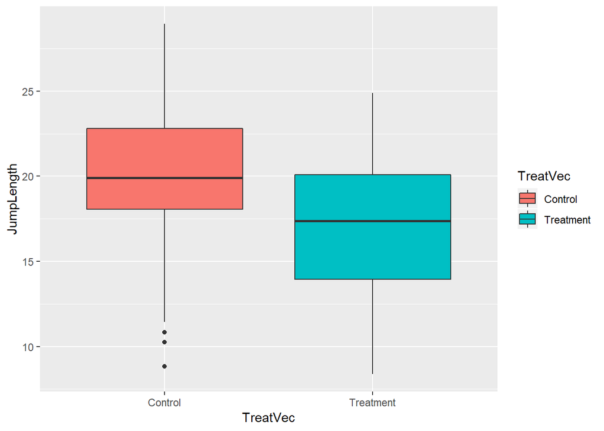

```r
ANOPlot <- ggplot(data=ANOdata,
                  aes(x=TreatVec,y=JumpLength,
                      fill=TreatVec)) +
  geom_boxplot()
print(ANOPlot)
```

### Running the analysis multiple times changes the P value, but all trials produced a significant P value, changing only slightly.

## After changing the mean values

```r
library(tidyverse)
## Control jump length before microscope consumption
CopejumpC <- rnorm(n=numbs,mean=18,sd=4)

## Variable jump length after microplastic consumption
CopejumpV <- rnorm(n=numbs,mean=16,sd=4)

ID <- seq_len(numbs)
dataset <- data.frame(ID,CopejumpC,CopejumpV)
print(dataset)
```

```
##      ID CopejumpC CopejumpV
## 1     1  8.967455 20.127817
## 2     2 25.899048 15.609667
## 3     3 16.383871 18.179024
## 4     4 24.978499 14.778337
## 5     5 27.389860 14.211248
## 6     6 26.783067 19.065366
## 7     7 16.671391 24.673862
## 8     8 22.161717 16.818158
## 9     9 15.016717 16.616416
## 10   10 14.101009 16.133392
## 11   11 16.661142 16.736791
## 12   12 11.278126  9.846612
## 13   13 16.991034 12.474487
## 14   14 16.569088 20.567875
```

[output cut: 86 more lines]

```r
## ANOVA analysis
nControl <- c("Control")
nTreatment <- c("Treatment")

TreatVec <- c(rep(nControl,numbs), rep(nTreatment,numbs))
head(TreatVec)
```

```
## [1] "Control" "Control" "Control" "Control" "Control" "Control"
```

```r
JumpLength <- c(CopejumpC,CopejumpV)
print(JumpLength)
```

```
##   [1]  8.967455 25.899048 16.383871 24.978499 27.389860 26.783067 16.671391
##   [8] 22.161717 15.016717 14.101009 16.661142 11.278126 16.991034 16.569088
##  [15] 22.400376 15.756259 18.354760 25.723175 22.009064 14.946650 10.621978
##  [22] 18.358949 19.637278 21.746965 19.882131 21.233142 20.149607 17.325793
##  [29] 15.902746 11.787914 14.073239 17.483355 16.325082 26.385228 14.340843
##  [36] 16.416422 19.142804 17.592854 14.545026 18.321473 18.731576 14.945080
##  [43] 15.574784 17.824655 20.355151 13.854850 17.396801 13.540543 20.194080
##  [50] 15.694285 19.526498 16.257785 17.431561 17.011726 18.930147 16.503112
##  [57] 18.764944 14.275272 15.126142 16.906445 19.542901 15.994390 17.306388
##  [64] 18.304740 19.209496 18.476829  9.519878 21.042107 24.406497 17.671925
##  [71] 22.551487 16.874617 16.461172 27.853149 11.170590 18.056150 19.636470
##  [78] 17.751810 13.111180 18.089852 13.709195 17.377449 21.293250 19.546367
##  [85] 18.776931 14.326206 18.208151 22.240642 19.127037 15.023876 15.686573
##  [92] 22.467383 15.609607 17.001755 21.294466 19.016241 20.279238 16.157604
##  [99] 20.252007 16.437217 20.127817 15.609667 18.179024 14.778337 14.211248
## [106] 19.065366 24.673862 16.818158 16.616416 16.133392 16.736791  9.846612
## [113] 12.474487 20.567875 15.526406 12.540521 11.540511 11.447339 14.027884
## [120] 11.098622 19.655209 17.048425 11.176724 14.106569 15.374066 10.772602
## [127] 10.871862 13.683814 23.142036 14.791155 12.012611 15.749502 12.153080
## [134] 13.373450 19.419123 21.221658 21.323865 19.151005 19.683659 13.819089
## [141] 25.617799  9.842354 18.801921 13.867565 15.364829 13.273423 16.776654
## [148] 18.837917 13.361787  9.803533 15.118199 12.325163 13.783188 12.994275
## [155]  9.021777 16.739985 16.777242 13.505344 20.537436 10.595702 23.742879
## [162] 18.915740 11.392963 15.569279  3.959834 20.617859 13.434381 15.886312
## [169] 13.552529 14.053208 13.543811 14.317433 11.766987 12.804628 10.866283
## [176] 14.465440 13.596608  6.267520 15.050260 10.706956 15.112466 12.395926
## [183] 18.169059 14.877900 12.466006 22.880636 17.078896 18.927539 21.261683
## [190] 14.567398 13.098993 19.222441 19.791243 20.694521 17.162129 20.042479
## [197] 14.872628 17.601951 13.217387 21.644322
```

```r
ANOdata <- data.frame(ID,TreatVec,JumpLength)
head(ANOdata)
```

```
##   ID TreatVec JumpLength
## 1  1  Control   8.967455
## 2  2  Control  25.899048
## 3  3  Control  16.383871
## 4  4  Control  24.978499
## 5  5  Control  27.389860
## 6  6  Control  26.783067
```

```r
ANOmodel <- aov(JumpLength~TreatVec,data=ANOdata)
print(ANOmodel)
```

```
## Call:
##    aov(formula = JumpLength ~ TreatVec, data = ANOdata)
##
## Terms:
##                  TreatVec Residuals
## Sum of Squares   309.8331 2942.3170
## Deg. of Freedom         1       198
##
## Residual standard error: 3.854891
## Estimated effects may be unbalanced
```

```r
summary(ANOmodel)
```

```
##              Df Sum Sq Mean Sq F value   Pr(>F)
## TreatVec      1  309.8  309.83   20.85 8.72e-06 ***
## Residuals   198 2942.3   14.86
## ---
## Signif. codes:  0 '***' 0.001 '**' 0.01 '*' 0.05 '.' 0.1 ' ' 1
```

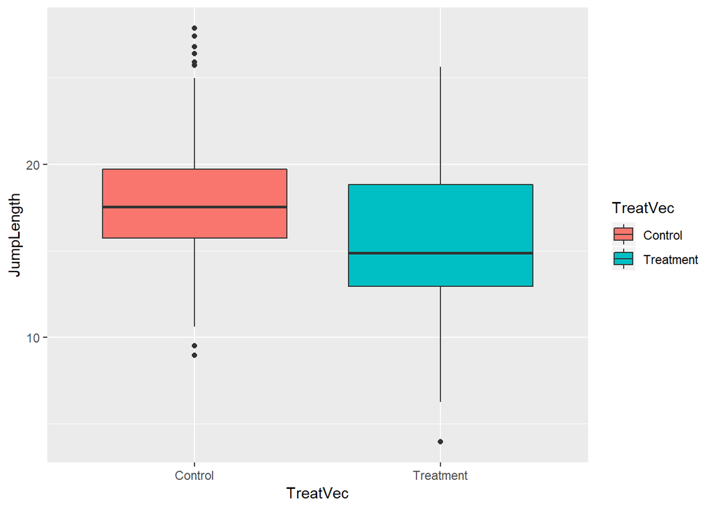

```r
ANOPlot <- ggplot(data=ANOdata,
                  aes(x=TreatVec,y=JumpLength,
                      fill=TreatVec)) +
  geom_boxplot()
print(ANOPlot)
```

### I decreased the mean values for both control and treatment groups, as well as decreased the difference between the two. I found that the P value was extremely less significant than the original means, although it is still statistically significant

```r
library(tidyverse)
numbs <- 24

####Control jump length before microscope consumption

CopejumpC <- rnorm(n=numbs,mean=20,sd=4)

####Variable jump length after microplastic consumption

CopejumpV <- rnorm(n=numbs,mean=17,sd=4)

ID <- seq_len(numbs)
dataset <- data.frame(ID,CopejumpC,CopejumpV)
print(dataset)
```

```
##    ID CopejumpC CopejumpV
## 1   1 21.726865 15.391538
## 2   2 24.915625 23.692487
## 3   3 17.765899 18.391113
## 4   4 24.827628 15.443565
## 5   5 23.409176 10.309856
## 6   6 19.665745  9.625329
## 7   7 26.897597 16.795522
## 8   8 21.363591 16.635918
## 9   9  8.108047 10.757698
## 10 10 21.250279 14.867561
## 11 11 15.985680 20.154916
## 12 12 19.152575 15.164060
## 13 13 19.845994 17.163046
## 14 14 21.627056 20.356490
## 15 15 18.243574 14.853794
## 16 16 20.899209 17.158833
## 17 17 25.574608  8.418645
## 18 18 23.681547  6.856539
## 19 19 16.511476 14.976531
## 20 20 15.905899 15.879451
## 21 21 20.031401 21.670769
## 22 22 27.278943 19.393769
## 23 23 28.870586 24.085753
## 24 24 17.312718 21.124534
```

```r
## ANOVA analysis

nControl <- c("Control")
nTreatment <- c("Treatment")

TreatVec <- c(rep(nControl,numbs), rep(nTreatment,numbs))
head(TreatVec)
```

```
## [1] "Control" "Control" "Control" "Control" "Control" "Control"
```

```r
JumpLength <- c(CopejumpC,CopejumpV)
print(JumpLength)
```

```
##  [1] 21.726865 24.915625 17.765899 24.827628 23.409176 19.665745 26.897597
##  [8] 21.363591  8.108047 21.250279 15.985680 19.152575 19.845994 21.627056
## [15] 18.243574 20.899209 25.574608 23.681547 16.511476 15.905899 20.031401
## [22] 27.278943 28.870586 17.312718 15.391538 23.692487 18.391113 15.443565
## [29] 10.309856  9.625329 16.795522 16.635918 10.757698 14.867561 20.154916
## [36] 15.164060 17.163046 20.356490 14.853794 17.158833  8.418645  6.856539
## [43] 14.976531 15.879451 21.670769 19.393769 24.085753 21.124534
```

```r
ANOdata <- data.frame(ID,TreatVec,JumpLength)
head(ANOdata)
```

```
##   ID TreatVec JumpLength
## 1  1  Control   21.72687
## 2  2  Control   24.91562
## 3  3  Control   17.76590
## 4  4  Control   24.82763
## 5  5  Control   23.40918
## 6  6  Control   19.66574
```

```r
ANOmodel <- aov(JumpLength~TreatVec,data=ANOdata)
print(ANOmodel)
```

```
## Call:
##    aov(formula = JumpLength ~ TreatVec, data = ANOdata)
##
## Terms:
##                 TreatVec Residuals
## Sum of Squares  259.8607  963.0125
## Deg. of Freedom        1        46
##
## Residual standard error: 4.575484
## Estimated effects may be unbalanced
```

```r
summary(ANOmodel)
```

```
##             Df Sum Sq Mean Sq F value   Pr(>F)
## TreatVec     1  259.9  259.86   12.41 0.000976 ***
## Residuals   46  963.0   20.94
## ---
## Signif. codes:  0 '***' 0.001 '**' 0.01 '*' 0.05 '.' 0.1 ' ' 1
```

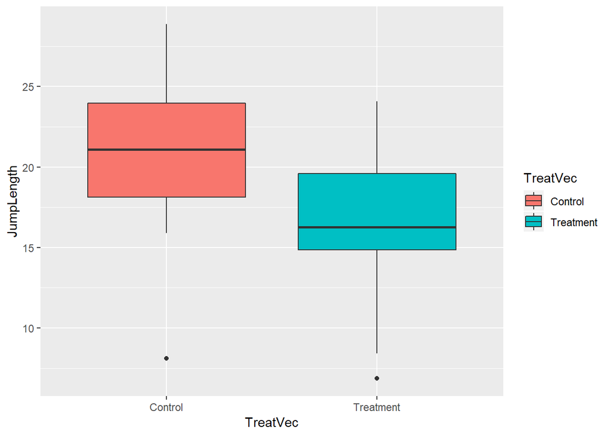

```r
ANOPlot <- ggplot(data=ANOdata,
                  aes(x=TreatVec,y=JumpLength,
                      fill=TreatVec)) +
  geom_boxplot()
print(ANOPlot)
```

[output not shown]